# Allocation Actifs Portefeuille

Julien Riton

10 décembre 2016

# 1 Objets d’étude

Nous suivons l’article de Natixis “ALLOCATION MULTI ACTIFS” ([NAT]) et l’article de William F. Sharpe datant de 1963 “A SIMPLIFIED MODEL FOR PORTFOLIO ANALYSIS” ([SHP]).

Pour les résultats affichés dans cette page depuis les calculs fait dans R, veuillez exécuter le script study1.R en cas de non affichage. Ce dernier script est en principe sourcé depuis ce présent fichier Rmd avec le bouton Knit HTML. Installer au préalable le package Rmarkdown.

```
## Copyright M. P. Wand 1997-2009
```

En page 4 de [NAT], il est fait mention de la non-normalité des rendements. Ce que l’on cherche à attester sur quelques valeurs telles que l’or (AUX) ou l’argent (AGX)

# 2 Rendement

Nous considérons comme définition du rendement:

si $(c_t)_{t=0,...,N}$ est la série temporelle représentant le cours d’une valeur, alors le rendement en $t=1,...,N$ est $r_t=\dfrac{c_t-c_{t-1}}{c_{t-1}}$.

## 2.1 Distribution du rendement de l’or

Dans un premier temps, nous regardons la distribution sur 20 ans des rendements mensuels de l’or.

Les cours sont données en $US depuis la page internet https://www.bullionvault.com/gold-price-chart.do

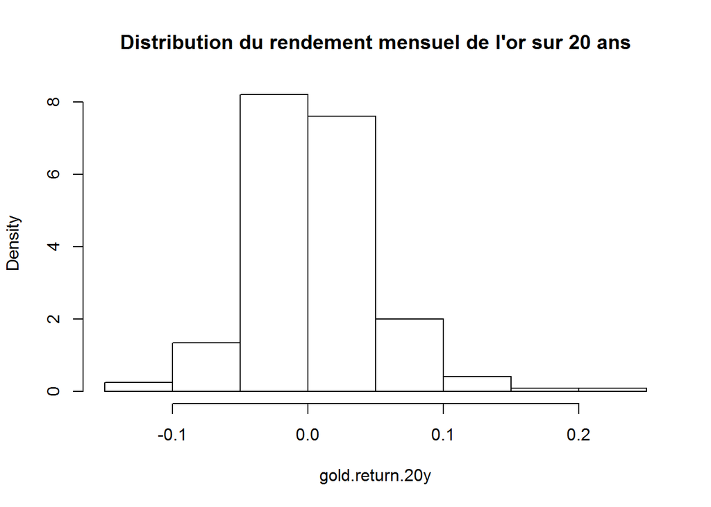

L’histogramme nous informe quelque peu sur une éventuelle distribution gaussienne. Nous réalisons alors un test de Shapiro:

```
##
##  Shapiro-Wilk normality test
##
## data:  gold.return.20y
## W = 0.96257, p-value = 6.668e-06
```

## 2.2 Distribution du rendement de l’argent

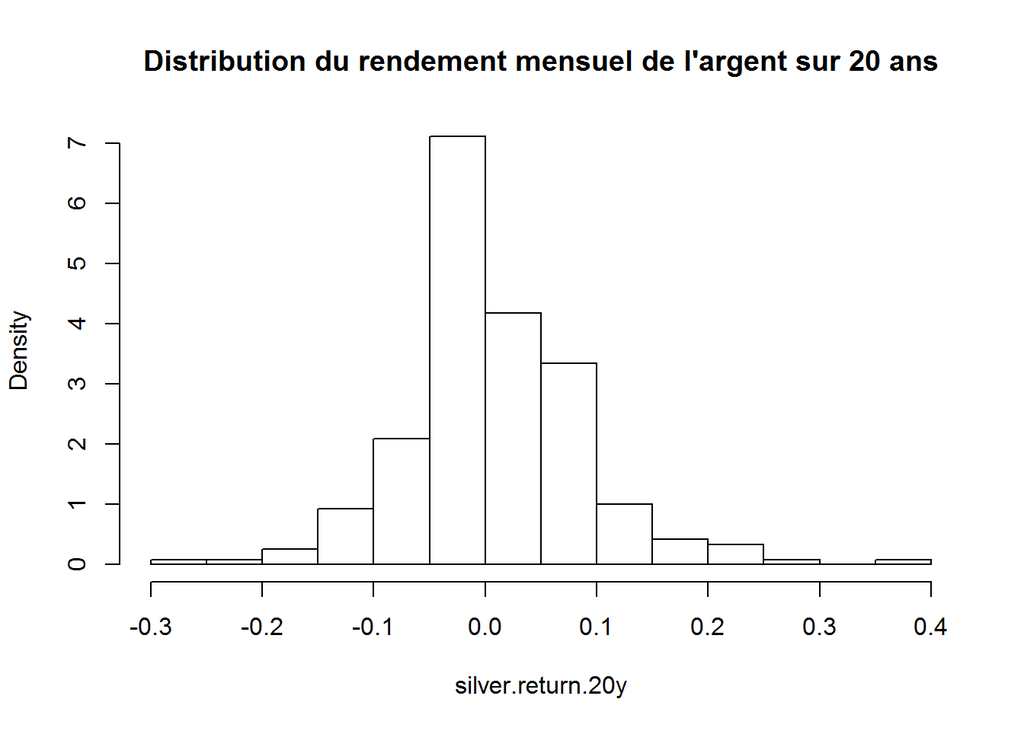

```
##
##  Shapiro-Wilk normality test
##
## data:  silver.return.20y
## W = 0.96186, p-value = 5.459e-06
```

### 2.2.1 distribution du rendement du pétrole

http://www.bdm.insee.fr/bdm2/affichageSeries?idbank=001565198&page=tableau&request_locale=fr

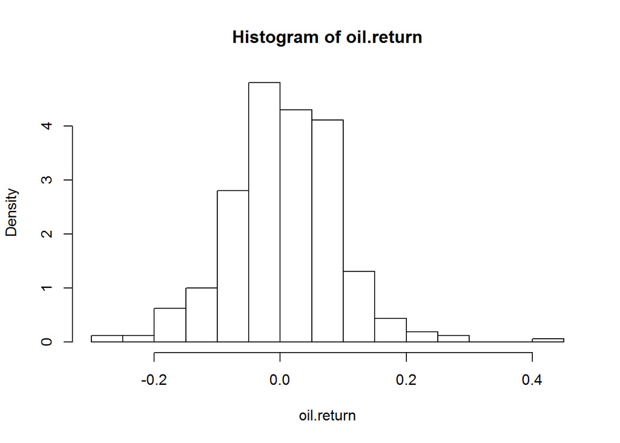

```
##
##  Shapiro-Wilk normality test
##
## data:  oil.return
## W = 0.97753, p-value = 6.418e-05
```

Encore ici, la p-value est nettement inférieure au risque de 5%.

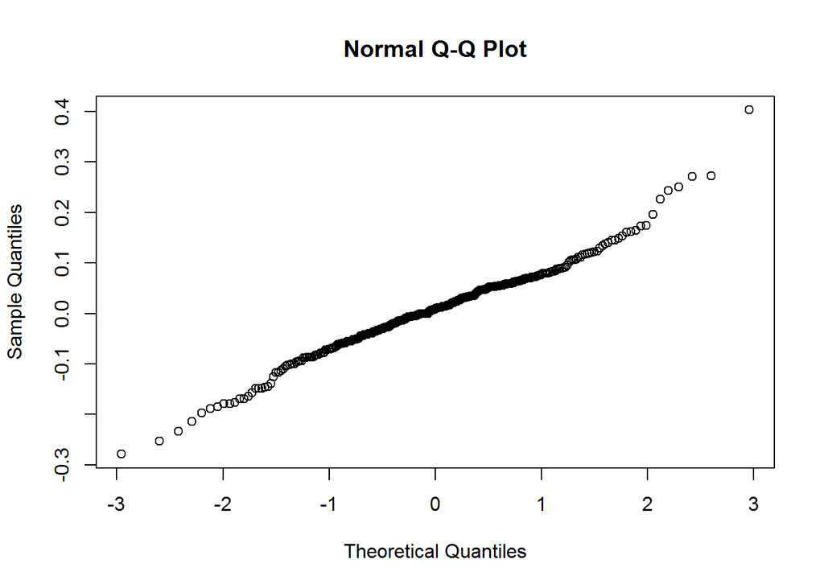

## 2.3 Distribution du rendement de Renault

https://www.euronext.com/fr/products/equities/FR0000131906-XPAR

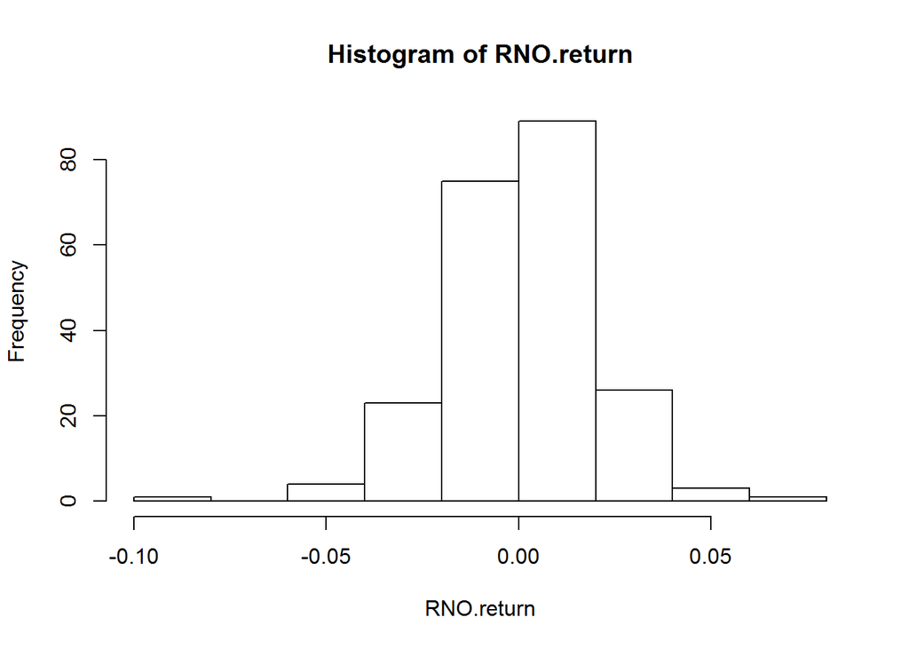

```
##
##  Shapiro-Wilk normality test
##
## data:  RNO.return
## W = 0.9763, p-value = 0.00087
```

Encore ici, la p-value est nettement inférieure au risque de 5%.

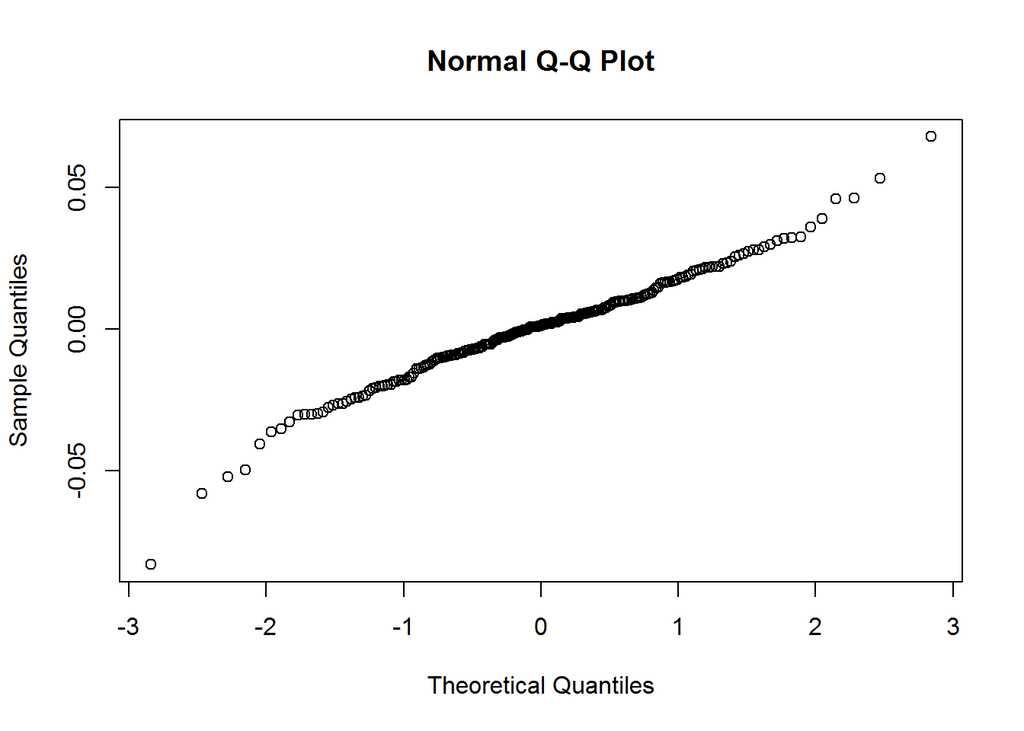

# 3 Risque

Pour la notion générale de risque, voir http://www.bnains.org/risque/risque.php#mesure,

# 4 Copules

Dans [NAT], il est fait mention de copules page 10. Entamons une étude d’après l’article (en anglais) de Wikipedia. https://en.wikipedia.org/wiki/Copula_(probability_theory)

Considérons la première définition donnée: “distribution multivariée pour laquelle les marginales sont uniformes”.
La fonction copule C est définie par
$$C(u_1,...,u_d)=\mathbb{P}\left[X_1\leq F_1^{-1}(u_1),...,X_d\leq F_d^{-1}(u_d)\right]$$

Nous allons jouer avec les distributions données par le rendement de l’or et de l’argent.

Premièrement, suivent leurs fonctions de répartitions empiriques:

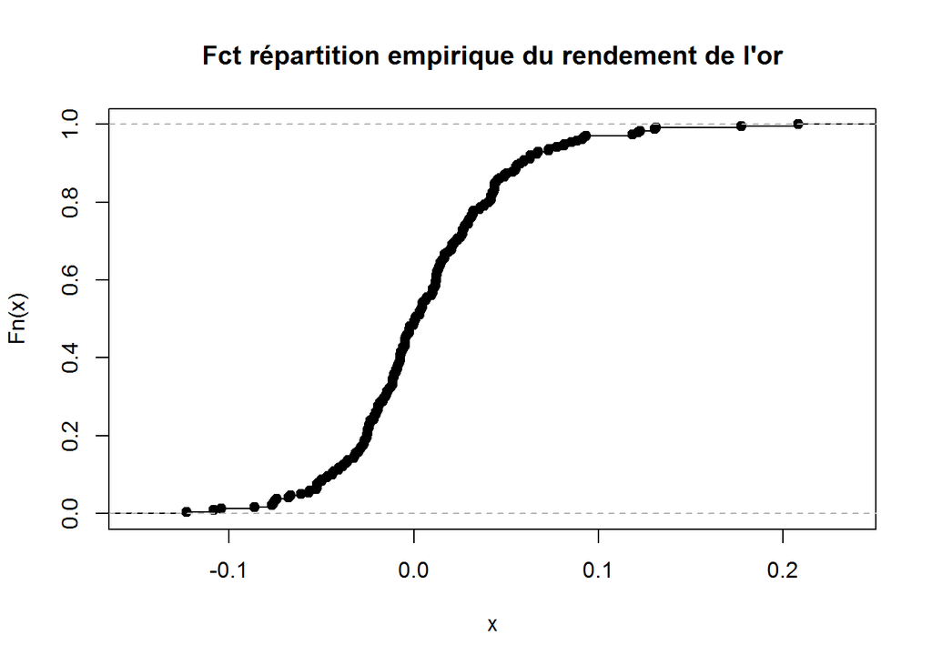

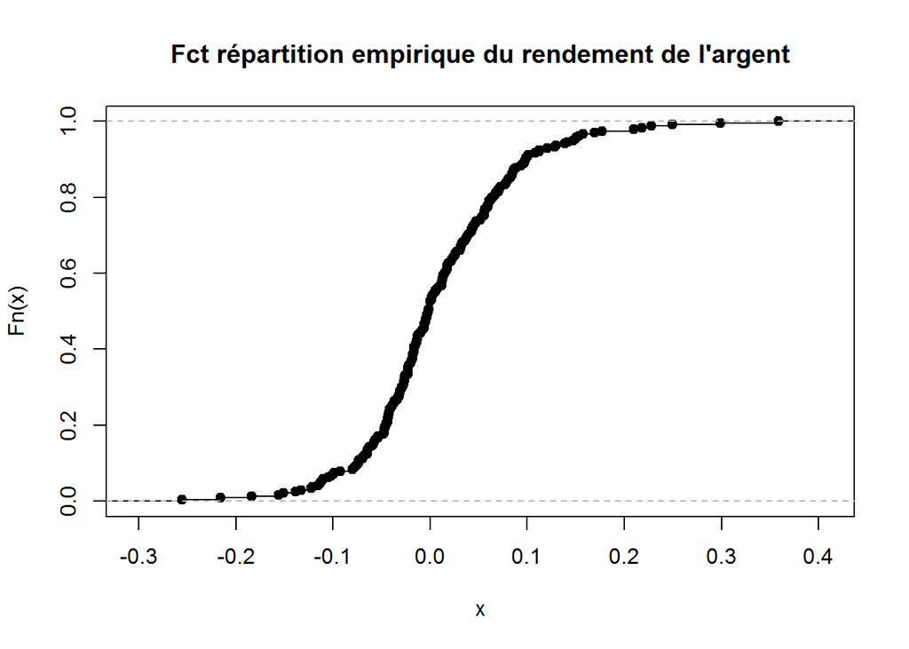

Nous estimerons $F_i^{-1}$ avec la fonction quantile de R (https://stat.ethz.ch/R-manual/R-devel/library/stats/html/quantile.html)

Pour la probabilité conjointe, nous avons une éventuelle solution avec le package ks: https://cran.r-project.org/web/packages/ks/vignettes/kde.pdf. L’utilisation minimaliste de la fonction ks::kde nous donne la distribution jointe suivante:

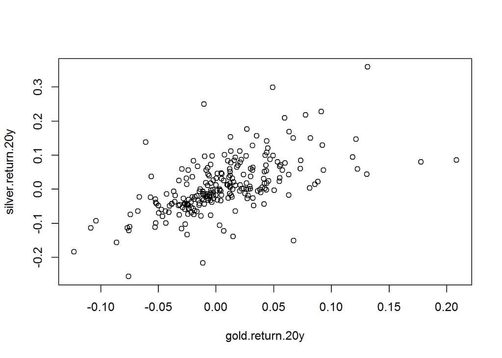

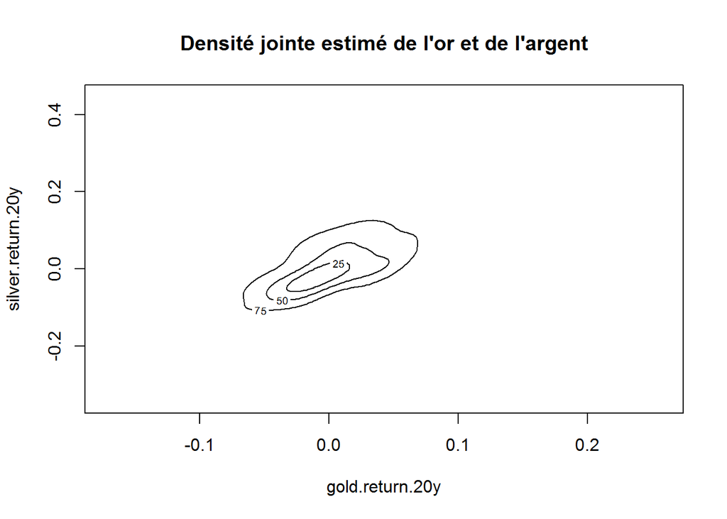

Les contours de régions de densités à 25%, 50% et 75% sont représentées.

Une incertitude demeure quant à l’évaluation de la densité conjointe: ici, nous avons consiéré l’or et l’argent évalués sur la même plage de temps. Nous avons donc mis en regard deux rendements correspondant à la même date.

On peut estimer $\mathbb{P}\left[X_1\leq a, X_2\leq b\right]$ par une méthode élémentaire comme une méthode des rectangles ou du point mileu bidimensionnelle qui sera “simple” à implémenter vue que le domaine d’intégration est rectangle. L’objet issu de `ks::kde` nous donne le champ `eval.point` qui représente la grille de points d’évaluation de la densité et le champ `estimate` qui donne la densité évaluée sur la grille de point. Il faut aussi penser à approcher un point rendu par les quantiles par un point de la grille.

Concernant ce dernier point, dans une première version de notre fonction d’intégration, cette approximation n’est pas vectorisable d’où l’usage de boucle for. De plus, chaque itération de la double boucle recalcule les sommes de Riemann alors qu’une seule fois est nécessaire.

## 4.1 Méthode du rectangle

Notre grille construite par ks::kde (n’oublions que l’on peut jouer sur cette construction) fournira un pavage de petits rectangles $R_{ij}$. On considèrera alors le coin supérieure droit $C_{ij}$ de chaque $R_{ij}$. Ensuite, nous ferons la somme de tous les produits $f(C_{ij})*S(R_{ij})$ tel que $C_{i,j} \leq (a,b)$.

## 4.2 Ce que l’on veut

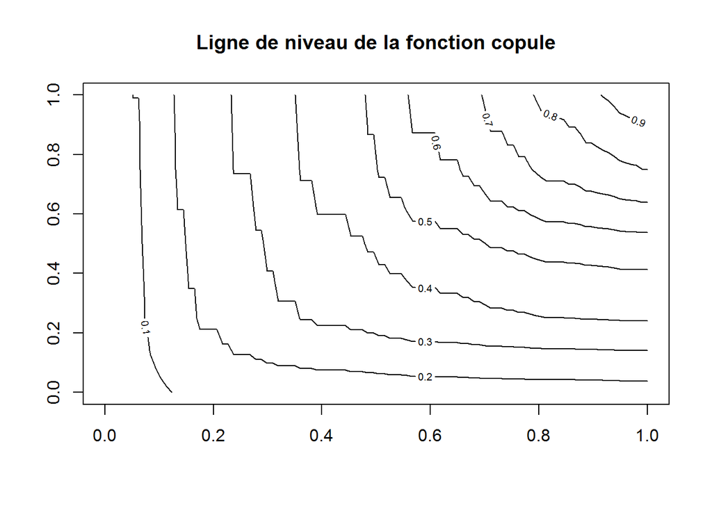

# 5 Modèle de Markovitz

```
## E_1= 0.006163658
```

```
## E_2= 0.008420855
```

```
## Matrice C de covariance:  0.002039797 0.002173862 0.002173862 0.00638248
```

## 5.1 Portefeuille efficient

Un portefeuille est efficient si aucun autre portefeuille donne:

- un rendement espéré plus grand et la même variance de rendement ou,
- une plus petite variance de portefeuille et le même rendement espéré.

Le problème devenant:  
Etant donné un ensemble de prédictions ,  
déterminer l’ensemble de portefeuille efficient.

## 5.2 Problème d’optimisation

$X_i$ est la proportion d’un portefeuille investi dans un titre $i$. On obtient

- $E=\sum_i X_i E_i$,
- $V = \sum_i\sum_j X_i X_j C_{ij}$.

La fonction objective étant pour un $\lambda$ donné
$$\begin{array}{ll}\phi & = \lambda E - V \\
& =\lambda \sum_i X_i E_i - \sum_i\sum_j X_i X_j C_{ij}
\end{array}$$

Etant donné $\lambda$, $E_i$ et $C_{ij}$, $\phi$ va évoluer avec $X_i$ soumis aux contraintes suivantes:

1. $\sum_i X_i = 1$, *ie* tout le portefeuille est investi
2. $X_i \geq 0$, *ie* qu’il n’y a pas de vente.

Dans le repère d’axe $(E,V)$, regardons quelle forme à la variété formé paramétré par les $X_i$ assujettis aux conditions précédentes.

Dans le cas de deux titres, nous obtenons un arc de parabole

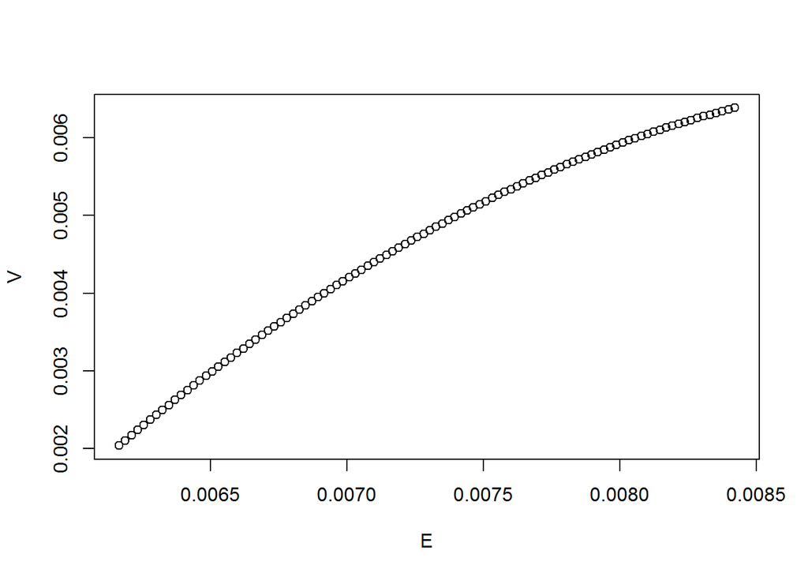

Topologiquement, nous avons dans $(E,V)$ un compact car image continue d’un simplexe. Etant compact, nous obtenons donc un bord. De plus, la paramétrisation étant différentiable car polynomiale nous avons des chances d’obtenir des coins (en fait au plus le nombre de coins du simplexe). Nous admettrons que l’on obtient une submersion d’un simplexe dans un plan.

Voir [Mkz] “Portfolio selection” avec l’exemple à trois titres.

# 6 Value at Risk (VaR)

La VaR est une information synthétique pour la direction d’une banque.  
Si nous disons; “Nous perdrons moins de V euros dans les N prcohaines jours avec une probabilité de X”, alors la variable V est la VaR du protefeuille à N jours au seuil X.  
Le régulateur utilise en générale $N=10$ et $X=99\%$, et s’intéresse à la perte potentielle qui sera dépassée avec une probabilité de 1%. Les capitaux requis sont alors au moins égaux à trois fois V selon la convention de Bâle.

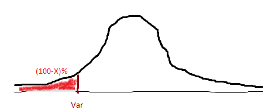

Calcul de la VaR au seuil de confiance X à partir d’une loi normale pour les variations de valeur du portefeuille

Lorsque $N$ est l’hotizon, $X$ le seuil de confiance, la VaR est le $100(1-X)$ centile de la distribution de probabilité des variations de valeur du portefeuille dans les $N$ jours à venir.

On calcule en général pour $N=1$, et on utilise
$$V(N;X)=V(1;X)*\sqrt{N}$$
formule exacte quand la distribution est gaussienne.